# Biostat276 Project 1

Zhaodong Wu

1/17/2022

```r
rm(list = ls())
library(ggplot2)
```

# 1. Sampling from the Banana Distribution

The two dimensional Banana distribution (Haario, 1999) is defined as:
$$\pi (x_1, x_2) \propto \text{exp}(-\frac{x_1^2}{2}) \ \text{exp} \left[ -\frac{\{ x_2-2(x_1^2-5)\}^2}{2} \right]; \quad x_1, x_2 \in \mathbb{R}.$$

$\textbf{(a)}$ Describe how to simulate directly from $\pi(x_1, x_2)$.

$\textbf{Solution: }$

From the information of joint probability-density function, we can know that the conditional probability of $x_2$ given $x_1$ is proportional to a normal kernel,
$$\pi (x_2 |x_1) = \frac{\pi(x_1, x_2)}{\pi(x_1)} \propto \text{exp} \left[ -\frac{\{ x_2-2(x_1^2-5)\}^2}{2} \right]$$

Therefore we can have
$$\pi (x_2 |x_1) = c * \text{exp} \left[ -\frac{\{ x_2-2(x_1^2-5)\}^2}{2} \right], \quad \text{where }c=\frac{1}{\sqrt{2\pi}}$$

Then we can get the marginal distribution of $x_1$ is also proportional to a normal kernel:
$$\begin{eqnarray}
\pi(x_1) = \int_{-\infty}^{+\infty}\pi(x_1,x_2)dx_2 &\propto& \int_{-\infty}^{+\infty}
\text{exp}(-\frac{x_1^2}{2}) \ \text{exp} \left[ -\frac{\{ x_2-2(x_1^2-5)\}^2}{2} \right] dx_2 \nonumber \\
&=& \text{exp}(-\frac{x_1^2}{2}) \int_{-\infty}^{+\infty}\text{exp} \left[ -\frac{\{ x_2-2(x_1^2-5)\}^2}{2} \right] dx_2 \nonumber \\
&=& \sqrt{2\pi} \cdot \text{exp}(-\frac{x_1^2}{2}) \nonumber \\
&\propto& \text{exp}(-\frac{x_1^2}{2}) \nonumber
\end{eqnarray}$$

Therefore we can get $x_1$ follows a standard normal distribution:
$$\pi (x_1) = \frac{1}{\sqrt{2\pi}} \cdot \text{exp}(-\frac{x_1^2}{2})$$

We can use inverse-transformation method to do the simulation:

We generate a R.V. $u \sim Uniform(0, 1)$ and take $x_1 = \Phi^{-1}(u)$;

Then we generate another R.V. $v \sim Uniform(0, 1)$ and take $x_2 = \Phi^{-1}(v) + 2(x_1^2-5)$ since $x_2 -2(x_1^2-5) | x_1 \sim N(0, 1)$.

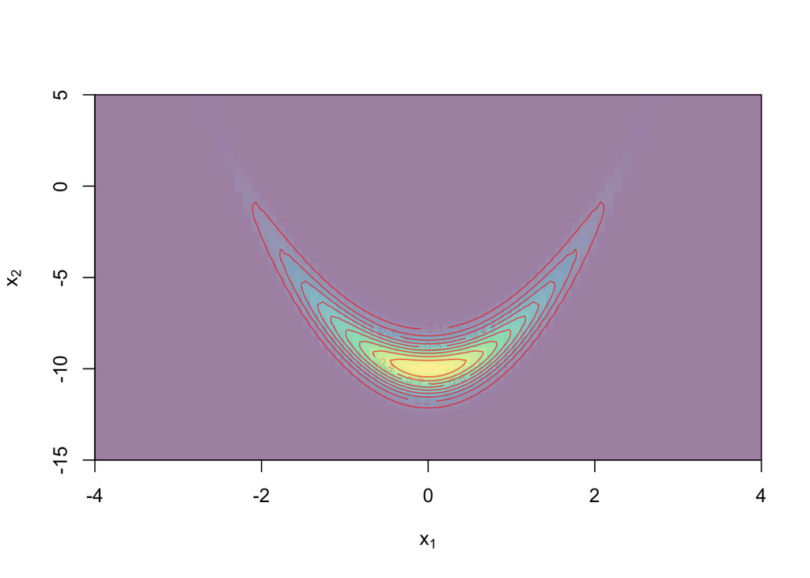

```r
# generate x1, x2
nsim_Q1 = 100
x1 <- seq(-5, 5, length.out = nsim_Q1)
x2 <- seq(-15, 5, length.out = nsim_Q1)
mat <- matrix(0, nsim_Q1, nsim_Q1)

# define banana distribution
banana_Q1 <- function(x1, x2) {
  fx1x2 <- exp(-(x1^2)/2)*exp(-((x2-2*(x1^2-5))^2)/2)
  return(fx1x2)
}

# plug in values
for (i in 1:nsim_Q1) {
  for (j in 1:nsim_Q1) {
    x = x1[i]
    y = x2[j]
    mat[i,j] = banana_Q1(x,y)
  }
}

# plot contour image
image(x1, x2, mat, col = hcl.colors(100, alpha = 0.5), xlim = c(-4, 4),
     ylim = c(-15, 5),
      xlab = expression(x[1]),
      ylab = expression(x[2]))
contour(x1, x2, mat, add = T, col = rgb(1, 0, 0,alpha = 0.6))
```

$\text{(b)}$ Describe how to simulate from $\pi(x_1,x_2)$ using the accept-reject method. Implement your algorithm and discuss sampling efficiency in relation to the chosen instrument distribution.

$\textbf{Solution: }$ For the accept-reject method we need to evaluate the normalizing constant $M$ such that:
$$\pi (x_1, x_2) \le M \cdot g(x_1, x_2), \quad \forall x_1, x_2 \in \mathbb{R}$$

```r
#define banana distribution again for simplicity of Q2
banana_Q2 <- function(x) {
  x1 = x[1]
  x2 = x[2]
  fx1x2 <- exp(-x1^2/2)*exp(-(x2-2*(x1^2-5))^2/2)
}

library(mvtnorm)
acc_rej <- function(nsim, M, sd = 40, seed_Q2 = 1998) {
  set.seed(seed_Q2)
  # generate g(x)- a multivariate t distribution
  x <- rmvt(n = nsim, sigma = diag(sd, 2), df = 6, delta = c(0, -10),
            type = "shifted")
  # generate u ~ U[0, 1]
  u <- runif(nsim)
  Accept <- vector()
  u1 <- vector()
  c <- vector()
  yy <- vector()
  for (i in 1:nsim) {
    gx = dmvt(x = x[i, ], sigma = diag(sd, 2), df = 6, delta = c(0, -10),
              log = FALSE, type = "shifted")
    # check if the condition that f(x) <= M*g(x) is satisfied
    if (banana_Q2(x[i, ]) > M*gx) {
      print(i)
      print(x[i, ])
      print(banana_Q2(x[i, ]))
      print(M*gx)
      stop("The condition fails")
    }
    # accept y = x if u <= f(x)/(M*g(x))
    if (u[i] <= banana_Q2(x[i, ])/(M*gx)) {
      Accept[i] <- TRUE
      u1[i] <- u[i]
      c[i] <- banana_Q2(x[i, ])/(M*gx)
      yy[i] <- M*gx*u[i]
    } else {
      Accept[i] <- FALSE
      u1[i] = u[i]
      c[i] = banana_Q2(x[i, ])/(M*gx)
      yy[i] <- M*gx*u[i]
    }
  }
  return(list(x1 = x[, 1], x2 = x[, 2], Accept = Accept, u1 = u1, c = c,
              yy = yy))
}
Q2 <- acc_rej(10000, 1000)
# accuracy
sum(Q2$Accept)/length(Q2$Accept) # accuracy is low, about 0.005
```

```
## [1] 0.0051
```

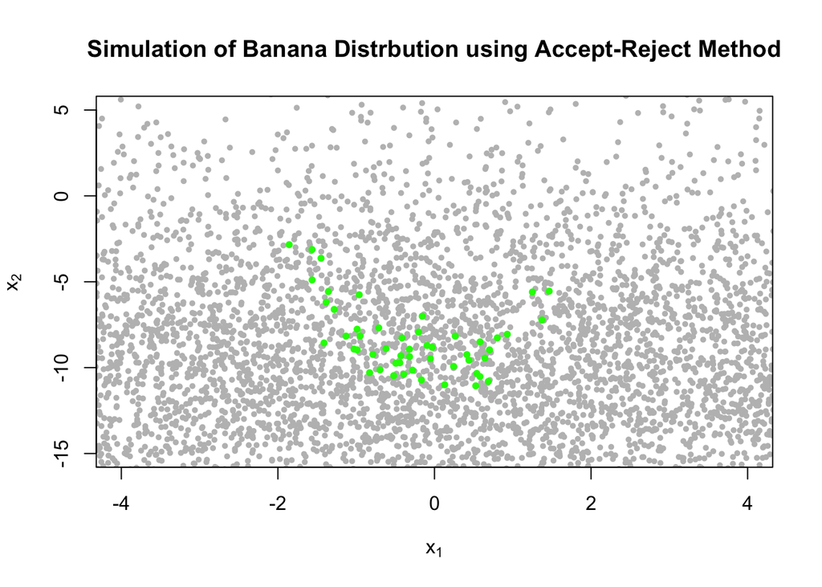

```r
# plot
plot(Q2$x1, Q2$x2, xlim = c(-4, 4), pch = 20, cex = 0.8, col = "grey",
     ylim = c(-15, 5), xlab = expression(x[1]), ylab = expression(x[2]),
     main = "Simulation of Banana Distrbution using Accept-Reject Method")
points(Q2$x1[Q2$Accept == "TRUE"], Q2$x2[Q2$Accept == "TRUE"],
       pch = 20, col = "green")
```

$\textbf{(c)}$ Describe how to simulate from π(x1,x2) using sampling importance resampling. Implement your algorithm and discuss sampling efficiency in relation to the chosen importance distribution.